# NGS sequence analysis with R / Bioconductor: RNA-Seq workflow

Author: Rakesh Kaundal (rkaundal@ucr.edu)

Last update: 11 March, 2016

# 1 Integrated Development Environment (IDE) for R

1. **RStudio**: a new Alternative Working Environment for R that works well for beginners and developers ([Homepage](https://www.rstudio.com/))

[figure not shown]

- Some useful keyboard shortcuts:
  - Ctrl+Enter (run current line code / selection)
  - Ctrl+Shift+C (comment / uncomment current line / selection)
  - Ctrl+2 (move cursor to console)
  - see more shortcuts at [Link](https://support.rstudio.com/hc/en-us/articles/200711853-Keyboard-Shortcuts)

[Back to Table of Contents](http://biocluster.ucr.edu/~rkaundal/workshops/R_mar2016/RNAseq.html)

# 2 Bioconductor

## 2.1 What is Bioconductor

- **Bioconductor** provides R packages for the analysis of genomic data, tools for analysis of data from next-generation high-throughput sequencing methods ([Link](https://www.bioconductor.org/))
  - 1104 packages for bioscience data analysis (*as of March 10, 2016*)
  - active user community, open source and open development
  - two releases each year
- Statistical analysis: large data, technological artifacts, designed experiments; rigorous
- Comprehension: biological context, visualization, reproducibility
- High-throughput
  - Sequencing: RNASeq, ChIPSeq, variants, copy number, …
  - Microarrays: expression, SNP, …
  - Flow cytometry, proteomics, images, …

Packages, vignettes, work flows

- ‘Release’ (every six months) and ‘devel’ branches
- Choose from 1104 packages:
  - Discover packages via [biocViews](http://bioconductor.org/packages/devel/BiocViews.html#___Software)
  - Each Package has a Package ‘landing page’ with Title, author / maintainer, short description, citation, installation instructions, shields, documentation, download statistics
  - All user-visible functions have help pages, most with runnable examples
  - ‘Vignettes’ an important feature in Bioconductor – narrative documents illustrating how to use the package, with integrated code

Helpful Links

- Documentation [Previous Course Material](http://bioconductor.org/help/course-materials/), [Workflows](http://bioconductor.org/help/workflows/), [Videos](https://www.youtube.com/user/bioconductor), [Developers](http://bioconductor.org/developers/)
- Ask a question [Support site](https://support.bioconductor.org/)
- Connect with Bioc [Twitter](https://twitter.com/Bioconductor), [Newsletter](http://bioconductor.org/help/newsletters/2015_July/)

[Back to Table of Contents](http://biocluster.ucr.edu/~rkaundal/workshops/R_mar2016/RNAseq.html)

## 2.2 Install Bioconductor Packages

Use the `biocLite.R` script to install Bioconductor packages. To install core packages, type the following in an R command window:

```
source("http://bioconductor.org/biocLite.R")
biocLite()
```

Install specific packages, e.g., “GenomicFeatures” and “AnnotationDbi”, with

```
biocLite(c("GenomicFeatures", "AnnotationDbi"))
```

## 2.3 Update Installed Bioconductor Packages

Bioconductor packages, especially those in the development branch, are updated fairly regularly. To identify packages requiring update within your version of Bioconductor, start a new session of R and enter

```
source("http://bioconductor.org/biocLite.R")
biocLite()                  ## R version 3.0 or later
```

## 2.4 Upgrading installed Bioconductor packages

Some versions of R support more than one version of Bioconductor. To use the latest version of Bioconductor for your version of R, enter

```
source("http://bioconductor.org/biocLite.R")
biocLite("BiocUpgrade")     ## R version 2.15 or later
```

Read the help page for `?BiocUpgrade` for additional details. Remember that more recent versions of Bioconductor may be available if your version of R is out-of-date.

[Back to Table of Contents](http://biocluster.ucr.edu/~rkaundal/workshops/R_mar2016/RNAseq.html)

## 2.5 Bioconductor Workflows

Bioconductor provides software to help analyze diverse high-throughput genomic data. Common workflows include:

### 2.5.1 Basic Workflows

- Sequence Analysis: Import fasta, fastq, BAM, gff, bed, wig, and other sequence formats. Trim, transform, align, and manipulate sequences. Perform quality assessment, ChIP-seq, differential expression, RNA-seq, and other workflows. Access the Sequence Read Archive.
- Oligonucleotide Arrays: Import Affymetrix, Illumina, Nimblegen, Agilent, and other platforms. Perform quality assessment, normalization, differential expression, clustering, classification, gene set enrichment, genetical genomics and other workflows for expression, exon, copy number, SNP, methylation and other assays. Access GEO, ArrayExpress, Biomart, UCSC, and other community resources.
- Annotation Resources: Introduction to using gene, pathway, gene ontology, homology annotations and the AnnotationHub. Access GO, KEGG, NCBI, Biomart, UCSC, vendor, and other sources.
- Annotating Genomic Ranges: Represent common sequence data types (e.g., from BAM, gff, bed, and wig files) as genomic ranges for simple and advanced range-based queries.
- Annotating Genomic Variants: Read and write VCF files. Identify structural location of variants and compute amino acid coding changes for non-synonymous variants. Use SIFT and PolyPhen database packages to predict consequence of amino acid coding changes.
- Changing genomic coordinate systems: rtracklayer, etc.

### 2.5.2 Advanced Workflows

- **RNA-Seq workflow**: gene-level exploratory analysis and differential expression
- High Throughput Assays: Import, transform, edit, analyze and visualize flow cytometric, mass spec, HTqPCR, cell-based, and other assays
- Mass spectrometry and proteomics
- Transcription Factor Binding: Finding Candidate Binding Sites for Known Transcription Factors via Sequence Matching.
- Cloud-enabled cis-eQTL search and annotation
- Differential Binding from ChIP-seq data.

# 3 Overview of RNA-Seq

RNA-seq is a high resolution Next-Generation Sequencing (NGS) method to assess the transcriptome of an organism and compare transcriptional changes between organisms / treatments to ascertain specific pathways / genes that are moving in response. With this powerful approach, one can:  
- Measure gene expression,  
- Discover and annotate complete transcripts,  
- Characterize alternative splicing and polyadenylation.

The types of information that can be gained from RNA-seq can be divided into two broad categories: qualitative and quantitative.

1. **Qualitative data** includes identifying expressed transcripts, and identifying exon/intron boundaries, transcriptional start sites (TSS), and poly-A sites. Here, we can refer to this type of information as “annotation”.
2. **Quantitative data** includes measuring differences in expression, alternative splicing, alternative TSS, and alternative polyadenylation between two or more treatments or groups. Here we focus specifically on experiments to measure differential gene expression (DGE).

These two types of data are related and to some extent, are inseparable. For instance, high quality annotation can lead to greater accuracy in mapping which can lead to the higher quality measures of gene expression. Similarly, accurate annotation requires some degree of quantification.

Today, we will walk through a gene-level RNA-seq differential expression workflow using Bioconductor packages. We will start from some sample FASTQ files, see how these were aligned to the reference genome, and prepare a count matrix which tallies the number of RNA-seq reads within each gene for each sample. We will then perform quality assessment and explore the relationship between samples, perform differential gene expression analysis, and visually explore the results.

## 3.1 RNA-Seq Technology

A typical RNA-seq experiment consists of the following steps:

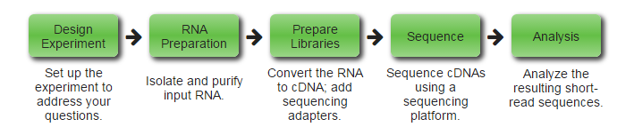

[figure not shown]

**Figure 1:** Overview of RNA-seq technology.

[Back to Table of Contents](http://biocluster.ucr.edu/~rkaundal/workshops/R_mar2016/RNAseq.html)

## 3.2 NGS data types

### 3.2.1 Raw: Sequencing Reads (FASTQ)

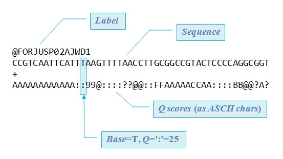

- A FASTQ file normally uses four lines per sequence.
- Line 1 begins with a ‘@’ character and is followed by a sequence identifier.
- Line 2 is the raw sequence letters.
- Line 3 begins with a ‘+’ character, is optionally followed by the same sequence identifier.
- Line 4 encodes the Phred quality values for the sequence in line 2, each value represents the error probability of a given base call.

**FASTQ Quality Scores**:

- Quality score represents the error probability of a given basecall
- In a FASTQ file, quality scores are often represented using the ASCII alphabet
- For example, a Phred score of 40 can be represented as the ASCII char “I” (40+33= ASCII #73), and an Illumina score of 40 as “h” (40+64=ASCII #104)
- The range of scores will depend on the technology and the base caller used, but will typically be up to 40.

### 3.2.2 Derived

- Alignments against reference genome
  - **SAM / BAM**: Sequence Alignment Map (SAM) is a tab-delimited alignment format consisting of a header section (lines starting with @) and an alignment section with 11 columns ([Link](https://samtools.github.io/hts-specs/SAMv1.pdf)). BAM is the compressed, indexed and binary version of this format. The below sample alignment contains the following features: (1) bases in lower cases are clipped from the alignment; (2) read r001/1 and r001/2 constitute a read pair; (3) r003 is a chimeric read; (4) r004 represents a split alignment.

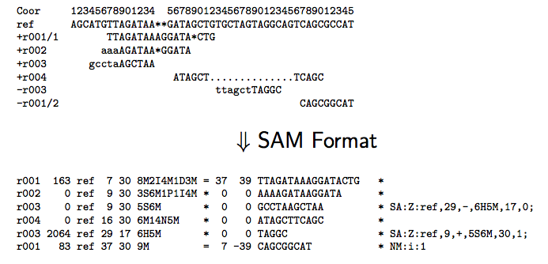

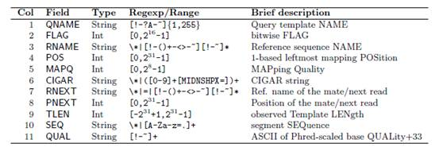

[Back to Table of Contents](http://biocluster.ucr.edu/~rkaundal/workshops/R_mar2016/RNAseq.html)

- Annotations
  - **GFF / GTF**

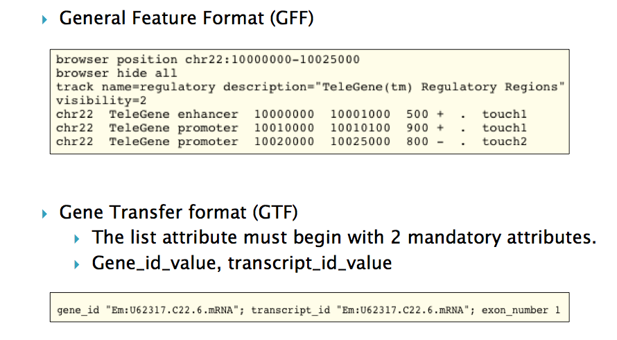

  - **GFF3**

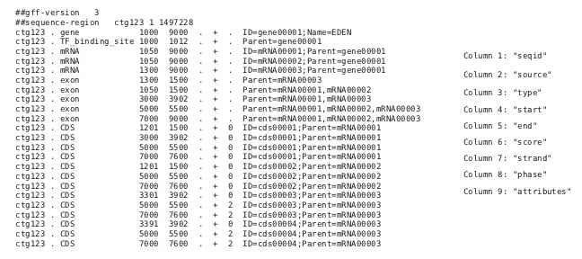

[Back to Table of Contents](http://biocluster.ucr.edu/~rkaundal/workshops/R_mar2016/RNAseq.html)

## 3.3 Analysis Workflow of RNA-Seq Gene Expression Data

1. Alignment of RNA reads to reference
   - Reference can be genome or transcriptome.
2. Count reads overlapping with annotation features of interest
   - Most common: counts for exonic gene regions, but many viable alternatives exist here: counts per exons, genes, introns, etc.
3. Normalization
   - Main adjustment for sequencing depth and compositional bias.
4. Identification of Differentially Expressed Genes (DEGs)
   - Identification of genes with significant expression differences.
   - Identification of expressed genes possible for strongly expressed ones.
5. Specialty applications
   - Splice variant discovery (semi-quantitative), gene discovery, antisense expressions, etc.
6. Cluster Analysis
   - Identification of genes with similar expression profiles across many samples.
7. Enrichment Analysis of Functional Annotations
   - Gene ontology analysis of obtained gene sets from steps 5-6.

## 3.4 Important Considerations for NGS Alignments

- The primary goal of Differential Gene Expression (DGE) is to quantitatively measure differences in the levels of transcripts between two or more treatments or groups.
- At one level, this is as simple as comparing the counts for reads that come from each transcript. However, there is no way to know how accurately such counts reflect what was actually present in the original sample, and there is no indication of how widely expression normally varies in a given group or without treatment. Therefore, in order to accurately interpret differences in read counts, one must also obtain information regarding the variances that are associated with these numbers; **biological replicates**.
- In NGS, we usually want to find the **origin of reads** (NG sequences) in a reference genome or transcriptome. Thus, we are mostly interested in finding the best scoring or multiple best scoring locations for each read, but not lower scoring alternative solutions as in paralog/ortholog search applications.
- **Ambiguous mappings** should be removed, because there is no evidence for their origin. However, for certain applications one needs to include them, e.g. when mapping RNA-Seq reads against transcript sequences instead of genome.

[Back to Table of Contents](http://biocluster.ucr.edu/~rkaundal/workshops/R_mar2016/RNAseq.html)

## 3.5 Normalization

- Libraries differ in size (total counted reads per sample) for un-interesting reasons; we need to account for differences in library size in statistical analysis.
- Total number of counted reads per sample is not a good estimate of library size. It is un-necessarily influenced by regions with large counts, and can introduce bias and correlation across genes. Instead, use a robust measure of library size that takes account of skew in the distribution of counts (simplest: trimmed geometric mean).
- Library size (total number of counted reads) differs between samples, and should be included as a statistical offset in analysis of differential expression, rather than ‘dividing by’ the library size early in an analysis.

### 3.5.1 Careful with RPKM/FPKM Values

RPKM Concept (FPKM is paired-end version of it)  
- RPKM (FPKM): **reads (fragments) per kb per million mapped reads**  
- For a given gene, larger counts imply more information; RPKM etc., treat all estimates as equally informative  
- RPKM/FPKM are not suitable for statistical testing. Why?  
- Consider the following example: in two libraries, each with one million reads, gene X may have 10 reads for treatment A and 5 reads for treatment B, while it is 100x as many after sequencing 100 millions reads from each library. In the latter case, we can be much more confident that there is a true difference between the two treatments than in the first one. However, the RPKM values would be the same for both scenarios.  
- Thus, RPKM/FPKM are useful for reporting expression values, but not for statistical testing!

Programs like edgeR and DESeq2 want to make use of the count nature of RNA-Seq data to increase statistical power. See here a simplified toy example:

**Scenario 1**: a 30000-bp transcript has 1000 counts in sample A and 700 counts in sample B.

**Scenario 2**: a 300-bp transcript has 10 counts in sample A and 7 counts in sample B.

Assume that the sequencing depths are the same in both samples and both scenarios. Then the **RPKM is the same** in sample A in both scenarios, and in sample B in both scenarios. In scenario A, we can be more confident that there is a true difference in the expression level than in scenario B (although we would want replicates of course).

**The following should make it more clear**:

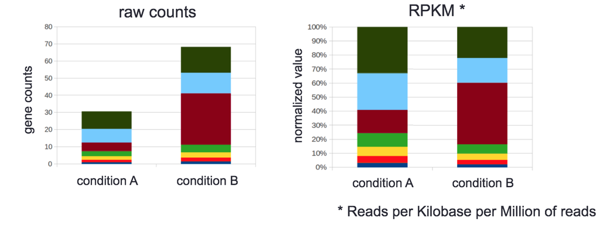

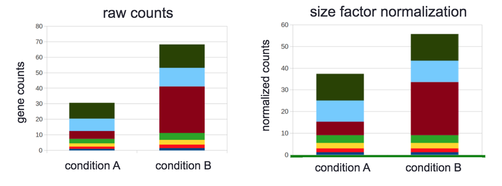

Every stack of the bar plot represents the number of counts of one gene. In this example you have 1.5 more depth in condition B compared to condition A. Only one gene (red) is differentially expressed. With the RPKM normalization, all the other genes will look downregulated in the second sample (which is wrong). The size-factor normalization can instead produce values which are stable for all the genes (implemented in [DESeq2](http://bioconductor.org/packages/release/bioc/manuals/DESeq2/man/DESeq2.pdf)).

[Back to Table of Contents](http://biocluster.ucr.edu/~rkaundal/workshops/R_mar2016/RNAseq.html)

### 3.5.2 RNA-Seq Data Normalization Methods

- **Total count (TC)**: Gene counts are divided by the total number of mapped reads (or library size) associated with their lane and multiplied by the mean total count across all the samples of the dataset.
- **Upper Quartile (UQ)**: Very similar in principle to TC, the total counts are replaced by the upper quartile of counts different from 0 in the computation of the normalization factors.
- **Median (Med)**: Also similar to TC, the total counts are replaced by the median counts different from 0 in the computation of the normalization factors. That is, the median is calculated as the median of gene counts of all runs.
- **DESeq**: This normalization method is included in the DESeq Bioconductor package and is based on the hypothesis that most genes are not DE. The method is based on a negative binomial distribution model, with variance and mean linked by local regression, and presents an implementation that gives scale factors. Within the DESeq package, and with the `estimateSizeFactorsForMatrix` function, scaling factors can be calculated for each run. After dividing gene counts by each scaling factor, DESeq values are calculated as the total of rescaled gene counts of all runs.
- **Trimmed Mean of M-values (TMM)**: This normalization method is implemented in the edgeR Bioconductor package (Robinson et al., 2010). It is also based on the hypothesis that most genes are not DE. Scaling factors are calculated using the `calcNormFactors` function in the package, and then rescaled gene counts are obtained by dividing gene counts by each scaling factor for each run. TMM is the sum of rescaled gene counts of all runs.
- **Quantile (Q)**: First proposed in the context of microarray data, this normalization method consists in matching distributions of gene counts across lanes.
- **Reads Per Kilobase per Million mapped reads (RPKM)**: This approach was initially introduced to facilitate comparisons between genes within a sample and combines between- and within-sample normalization. This approach quantifies gene expression from RNA-Seq data by normalizing for the total transcript length and the number of sequencing reads.

See comparison of various normalization techniques [here](http://www.rna-seqblog.com/which-method-should-you-use-for-normalization-of-rna-seq-data/).

## 3.6 Software for RNA-Seq DEG Analysis

- edgeR (Robinson et al., 2010)
- DESeq / DESeq2 (Anders and Huber, 2010, 2014)
- DEXSeq (Anders et al., 2012)
- limmaVoom
- Cuffdiff / Cuffdiff2 (Trapnell et al., 2013)
- PoissonSeq
- baySeq

# 4 RNA-Seq Analysis

## 4.1 Data Sets and Experimental Variables

The mini sample FASTQ files used in this overview vignette and the associated workflow reporting vignettes can be loaded via the `systemPipeRdata` package as shown below. The chosen data set [`SRP010938`](http://www.ncbi.nlm.nih.gov/sra/?term=SRP010938) contains 18 paired-end (PE) read sets from *Arabidposis thaliana* (Howard *et al*., 2013). To minimize processing time during testing, each FASTQ file has been subsetted to 90,000-100,000 randomly sampled PE reads that map to the first 100,000 nucleotides of each chromosome of the *A. thaliana* genome. The corresponding reference genome sequence (FASTA) and its GFF annotation files (provided in the same download) have been truncated accordingly. This way the entire test sample data set requires less than 200MB disk storage space.

In this RNA-Seq demo, we are using a Bioconductor package, `systemPipeR`, a R utility for building end-to-end analysis pipelines with automated report generation for next generation sequence (NGS) applications such as RNA-Seq, ChIP-Seq, VAR-Seq and Ribo-Seq (Girke T, 2015) [[Link](http://bioconductor.org/packages/release/bioc/html/systemPipeR.html)].

Start the analysis by opening in your R session the `RNAseq.R` script which contains the code shown in this vignette in pure text format. The following generates a fully populated `systemPipeR` workflow environment (here for RNA-Seq) in the current working directory of an R session:

```r
library(systemPipeRdata)
genWorkenvir(workflow="rnaseq")
setwd("rnaseq")
```

The working environment of the sample data as loaded above contains the following pre-configured directory structure:

- **workflow/** (*e.g.* *rnaseq/*)
  - This is the directory of the R session running the workflow.
  - Run script ( *.Rnw or *.Rmd) and sample annotation (*targets.txt*) files are located here.
  - Note, this directory can have any name (*e.g.* **rnaseq**, **varseq**). Changing its name does not require any modifications in the run script(s).
  - Important subdirectories:
    - **param/**
      - Stores parameter files such as: *.param, *.tmpl and *_run.sh.
    - **data/**
      - FASTQ samples
      - Reference FASTA file
      - Annotations
      - etc.
    - **results/**
      - Alignment, variant and peak files (BAM, VCF, BED)
      - Tabular result files
      - Images and plots
      - etc.

The following parameter files are included in each workflow template:

1. *`targets.txt`*: initial one provided by user; downstream *`targets_*.txt`* files are generated automatically
2. *`*.param`*: defines parameter for input/output file operations, *e.g.* *`trim.param`*, *`bwa.param`*, *`vartools.param`*, …
3. *`*_run.sh`*: optional bash script, *e.g.*: *`gatk_run.sh`*
4. Compute cluster environment (*skip on single machine*):
   - *`.BatchJobs`*: defines type of scheduler for *`BatchJobs`*
   - *`*.tmpl`*: specifies parameters of scheduler used by a system, *e.g.* Torque, SGE, StarCluster, Slurm, etc.

The sample workflows provided by this vignette are based on the above directory structure, where directory names are indicated in **grey**. Users can change this structure as needed, but need to adjust the code in their workflows accordingly.

[Back to Table of Contents](http://biocluster.ucr.edu/~rkaundal/workshops/R_mar2016/RNAseq.html)

### 4.1.1 Structure of *`targets`* file

#### 4.1.1.1 Structure of *`targets`* file for single end (SE) samples

```r
library(systemPipeR)
targetspath <- system.file("extdata", "targets.txt", package="systemPipeR")
read.delim(targetspath, comment.char = "#")
```

```
##                    FileName SampleName Factor SampleLong Experiment        Date
## 1  ./data/SRR446027_1.fastq        M1A     M1  Mock.1h.A          1 23-Mar-2012
## 2  ./data/SRR446028_1.fastq        M1B     M1  Mock.1h.B          1 23-Mar-2012
## 3  ./data/SRR446029_1.fastq        A1A     A1   Avr.1h.A          1 23-Mar-2012
## 4  ./data/SRR446030_1.fastq        A1B     A1   Avr.1h.B          1 23-Mar-2012
## 5  ./data/SRR446031_1.fastq        V1A     V1   Vir.1h.A          1 23-Mar-2012
## 6  ./data/SRR446032_1.fastq        V1B     V1   Vir.1h.B          1 23-Mar-2012
## 7  ./data/SRR446033_1.fastq        M6A     M6  Mock.6h.A          1 23-Mar-2012
## 8  ./data/SRR446034_1.fastq        M6B     M6  Mock.6h.B          1 23-Mar-2012
## 9  ./data/SRR446035_1.fastq        A6A     A6   Avr.6h.A          1 23-Mar-2012
## 10 ./data/SRR446036_1.fastq        A6B     A6   Avr.6h.B          1 23-Mar-2012
## 11 ./data/SRR446037_1.fastq        V6A     V6   Vir.6h.A          1 23-Mar-2012
## 12 ./data/SRR446038_1.fastq        V6B     V6   Vir.6h.B          1 23-Mar-2012
## 13 ./data/SRR446039_1.fastq       M12A    M12 Mock.12h.A          1 23-Mar-2012
## 14 ./data/SRR446040_1.fastq       M12B    M12 Mock.12h.B          1 23-Mar-2012
## 15 ./data/SRR446041_1.fastq       A12A    A12  Avr.12h.A          1 23-Mar-2012
## 16 ./data/SRR446042_1.fastq       A12B    A12  Avr.12h.B          1 23-Mar-2012
## 17 ./data/SRR446043_1.fastq       V12A    V12  Vir.12h.A          1 23-Mar-2012
## 18 ./data/SRR446044_1.fastq       V12B    V12  Vir.12h.B          1 23-Mar-2012
```

To work with the custom data, users need to generate a *`targets`* file containing the paths to their own FASTQ files and then provide under *`targetspath`* the path to the corresponding *`targets`* file.

[Back to Table of Contents](http://biocluster.ucr.edu/~rkaundal/workshops/R_mar2016/RNAseq.html)

#### 4.1.1.2 Structure of *`targets`* file for paired end (PE) samples

```r
targetspath <- system.file("extdata", "targetsPE.txt", package="systemPipeR")
read.delim(targetspath, comment.char = "#")[1:2,1:6]
```

```
##                  FileName1                FileName2 SampleName Factor SampleLong Experiment
## 1 ./data/SRR446027_1.fastq ./data/SRR446027_2.fastq        M1A     M1  Mock.1h.A          1
## 2 ./data/SRR446028_1.fastq ./data/SRR446028_2.fastq        M1B     M1  Mock.1h.B          1
```

#### 4.1.1.3 Sample comparisons

Sample comparisons are defined in the header lines of the *`targets`* file starting with ‘`# <CMP>`’.

```r
readLines(targetspath)[1:4]
```

```
## [1] "# Project ID: Arabidopsis - Pseudomonas alternative splicing study (SRA: SRP010938; PMID: 24098335)"
## [2] "# The following line(s) allow to specify the contrasts needed for comparative analyses, such as DEG identification. All possible comparisons can be specified with 'CMPset: ALL'."
## [3] "# <CMP> CMPset1: M1-A1, M1-V1, A1-V1, M6-A6, M6-V6, A6-V6, M12-A12, M12-V12, A12-V12"
## [4] "# <CMP> CMPset2: ALL"
```

The function *`readComp`* imports the comparison and stores them in a *`list`*. Alternatively, *`readComp`* can obtain the comparison information from the corresponding *`SYSargs`* object (see below). Note, the header lines are optional. They are mainly useful for controlling comparative analysis according to certain biological expectations, such as simple pairwise comparisons in RNA-Seq experiments.

```r
readComp(file=targetspath, format="vector", delim="-")
```

```
## $CMPset1
## [1] "M1-A1"   "M1-V1"   "A1-V1"   "M6-A6"   "M6-V6"   "A6-V6"   "M12-A12" "M12-V12" "A12-V12"
##
## $CMPset2
##  [1] "M1-A1"   "M1-V1"   "M1-M6"   "M1-A6"   "M1-V6"   "M1-M12"  "M1-A12"  "M1-V12"  "A1-V1"
## [10] "A1-M6"   "A1-A6"   "A1-V6"   "A1-M12"  "A1-A12"  "A1-V12"  "V1-M6"   "V1-A6"   "V1-V6"
## [19] "V1-M12"  "V1-A12"  "V1-V12"  "M6-A6"   "M6-V6"   "M6-M12"  "M6-A12"  "M6-V12"  "A6-V6"
## [28] "A6-M12"  "A6-A12"  "A6-V12"  "V6-M12"  "V6-A12"  "V6-V12"  "M12-A12" "M12-V12" "A12-V12"
```

[Back to Table of Contents](http://biocluster.ucr.edu/~rkaundal/workshops/R_mar2016/RNAseq.html)

### 4.1.2 Structure of *`param`* file and *`SYSargs`* container

The *`param`* file defines the parameters of the command-line software. The following shows the format of a sample *`param`* file provided by this package.

```r
parampath <- system.file("extdata", "tophat.param", package="systemPipeR")
read.delim(parampath, comment.char = "#")
```

```
##      PairSet         Name                                  Value
## 1    modules         <NA>                          bowtie2/2.1.0
## 2    modules         <NA>                          tophat/2.0.8b
## 3   software         <NA>                                 tophat
## 4      cores           -p                                      4
## 5      other         <NA> -g 1 --segment-length 25 -i 30 -I 3000
## 6   outfile1           -o                            <FileName1>
## 7   outfile1         path                             ./results/
## 8   outfile1       remove                                   <NA>
## 9   outfile1       append                                .tophat
## 10  outfile1 outextension              .tophat/accepted_hits.bam
## 11 reference         <NA>                    ./data/tair10.fasta
## 12   infile1         <NA>                            <FileName1>
## 13   infile1         path                                   <NA>
## 14   infile2         <NA>                            <FileName2>
## 15   infile2         path                                   <NA>
```

The *`systemArgs`* function imports the definitions of both the *`param`* file and the *`targets`* file, and stores all relevant information as *`SYSargs`* object. To run the pipeline without command-line software, one can assign *`NULL`* to *`sysma`* instead of a *`param`* file. In addition, one can start the *`systemPipeR`* workflow with pre-generated BAM files by providing a targets file where the *`FileName`* column gives the paths to the BAM files and *`sysma`* is assigned *`NULL`*. Note: in the following example, the usage of *`suppressWarnings()`* is only relevant for building this vignette. In typical workflows, this should be removed.

```r
args <- suppressWarnings(systemArgs(sysma=parampath, mytargets=targetspath))
args
```

```
## An instance of 'SYSargs' for running 'tophat' on 18 samples
```

Construct *`SYSargs`* object from *`param`* and *`targets`* files.

```r
args <- systemArgs(sysma="param/trim.param", mytargets="targetsPE.txt")
```

[Back to Table of Contents](http://biocluster.ucr.edu/~rkaundal/workshops/R_mar2016/RNAseq.html)

## 4.2 Read Preprocessing

The function *`preprocessReads`* allows to apply pre-defined or custom read pre-processing functions to all the FASTQ files referenced in a *`SYSargs`* container, such as quality filtering or adapter trimming routines. The paths to the resulting output FASTQ files are stored in the *`outpaths`* slot of the *`SYSargs`* object. Internally, *`preprocessReads`* uses the *`FastqStreamer`* function from the *`ShortRead`* package to stream through large FASTQ files in a memory-efficient manner. The following example performs adapter trimming with the *`trimLRPatterns`* function from the *`Biostrings`* package.

After the trimming step, a new targets file is generated (here *`targets_trim.txt`*) containing the paths to the trimmed FASTQ files. The new targets file can be used for the next workflow step with an updated *`SYSargs`* instance, *e.g.* running the NGS alignments with the trimmed FASTQ files.

```r
preprocessReads(args=args, Fct="trimLRPatterns(Rpattern='GCCCGGGTAA', subject=fq)",
                batchsize=100000, overwrite=TRUE, compress=TRUE)
writeTargetsout(x=args, file="targets_trim.txt")
```

The following example shows how to design a custom read pre-processing function using utilities provided by the *`ShortRead`* package, and then run it in batch mode with the *‘preprocessReads’* function (here on paired-end reads).

```r
args <- systemArgs(sysma="param/trimPE.param", mytargets="targetsPE.txt")
filterFct <- function(fq, cutoff=20, Nexceptions=0) {
    qcount <- rowSums(as(quality(fq), "matrix") <= cutoff)
    fq[qcount <= Nexceptions] # Retains reads where Phred scores are >= cutoff with N exceptions
}
preprocessReads(args=args, Fct="filterFct(fq, cutoff=20, Nexceptions=0)", batchsize=100000)
writeTargetsout(x=args, file="targets_PEtrim.txt")
```

[Back to Table of Contents](http://biocluster.ucr.edu/~rkaundal/workshops/R_mar2016/RNAseq.html)

## 4.3 FASTQ quality report

The following shows how to create read quality reports with the *`seeFastq`* function from **systemPipeR**. The *`seeFastq`* and *`seeFastqPlot`* functions generate and plot a series of useful quality statistics for a set of FASTQ files including per cycle quality box plots, base proportions, base-level quality trends, relative *k*-mer diversity, length and occurrence distribution of reads, number of reads above quality cutoffs and mean quality distribution ([Link](http://www.bioinformatics.babraham.ac.uk/projects/fastqc/)).

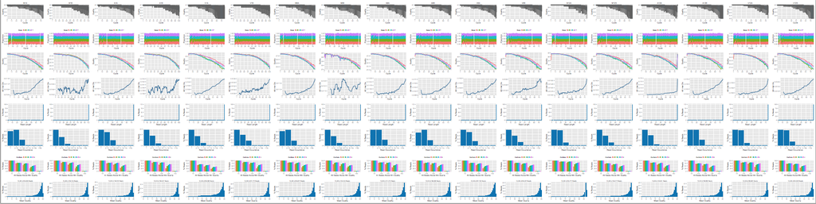

```r
fqlist <- seeFastq(fastq=infile1(args), batchsize=10000, klength=8)
pdf("./results/fastqReport.pdf", height=18, width=4*length(fqlist))
seeFastqPlot(fqlist)
dev.off()
```

**Figure 2:** QC report for 18 FASTQ files

[Back to Table of Contents](http://biocluster.ucr.edu/~rkaundal/workshops/R_mar2016/RNAseq.html)

Parallelization of QC report on a single machine with multiple cores

```r
args <- systemArgs(sysma="param/tophat.param", mytargets="targets_PEtrim.txt")
f <- function(x) seeFastq(fastq=infile1(args)[x], batchsize=100000, klength=8)
fqlist <- bplapply(seq(along=args), f, BPPARAM = MulticoreParam(workers=8))
pdf("./results/fastqReport_multicores.pdf", height=18, width=4*length(fqlist))
seeFastqPlot(unlist(fqlist, recursive=FALSE))
dev.off()
```

[Back to Table of Contents](http://biocluster.ucr.edu/~rkaundal/workshops/R_mar2016/RNAseq.html)

Parallelization of QC report via scheduler (*e.g.* Torque) across several compute nodes

```r
library(BiocParallel); library(BatchJobs)
f <- function(x) {
    library(systemPipeR)
    args <- systemArgs(sysma="param/tophat.param", mytargets="targets.txt")
    seeFastq(fastq=infile1(args)[x], batchsize=100000, klength=8)
}
funs <- makeClusterFunctionsTorque("torque.tmpl")
param <- BatchJobsParam(length(args), resources=list(walltime="20:00:00", nodes="1:ppn=1", memory="6gb"), cluster.functions=funs)
register(param)
fqlist <- bplapply(seq(along=args), f)
pdf("./results/fastqReport_clustergen.pdf", height=18, width=4*length(fqlist))
seeFastqPlot(unlist(fqlist, recursive=FALSE))
dev.off()
```

[Back to Table of Contents](http://biocluster.ucr.edu/~rkaundal/workshops/R_mar2016/RNAseq.html)

## 4.4 Alignments

### 4.4.1 Align Reads with *`TopHat2`*

*`TopHat2`* is a fast splice junction mapper for RNA-Seq reads ([Link](https://ccb.jhu.edu/software/tophat/index.shtml)). It aligns RNA-Seq reads to mammalian-sized genomes using the ultra high-throughput short read aligner *`Bowtie2`*, and then analyzes the mapping results to identify splice junctions between exons. Prior to running TopHat / TopHat2, an index from the reference genome should be built using Bowtie / Bowtie2. Moreover, TopHat2 requires both, the index file and the reference file, to be in the same directory. If the reference file is not available, TopHat2 reconstructs it in its initial step using the index file.

- **Index** the reference genome

```r
library(systemPipeR)
args <- systemArgs(sysma="./param/tophat.param", mytargets="targetsPE.txt")
moduleload(modules(args)) # Skip if a module system is not available
system("bowtie2-build ./data/tair10.fasta ./data/tair10.fasta")
```

Execute *`SYSargs`* on a single machine without submitting to a queuing system of a compute cluster. This way the input FASTQ files will be processed sequentially. If available, multiple CPU cores can be used for processing each file. The number of CPU cores (here 4) to use for each process is defined in the *`*.param`* file. With *`cores(args)`* one can return this value from the *`SYSargs`* object.

- **Align** all FASTQ files with Bowtie2/Tophat2 on a single computer. Includes generation of indexed BAM files

```r
bampaths <- runCommandline(args=args)
bampaths
```

- (**Optional**) Alternatively, one can align all FASTQ files with Bowtie2/Tophat2 on many compute nodes in parallel. The following submits to Torque scheduler 18 processes each with 4 CPU cores. The number of independent parallel cluster processes is defined under the *`Njobs`* argument. If the resources available on a cluster allow to run all 18 processes at the same time then the shown sample submission will utilize in total 72 CPU cores. To run the following code, one needs to have both a conf file (see *`.BatchJob`* samples [here](https://code.google.com/p/batchjobs/wiki/DortmundUsage)) and a template file (see *`*.tmpl`* samples [here](https://github.com/tudo-r/BatchJobs/tree/master/examples)) for the queueing available on a system. The following example uses the sample conf and template files for the Torque scheduler provided in this package.

```r
resources <- list(walltime="20:00:00", nodes=paste0("1:ppn=", cores(args)), memory="10gb")
reg <- clusterRun(args, conffile=".BatchJobs.R", template="torque.tmpl", Njobs=18, runid="01",
                  resourceList=resources)
waitForJobs(reg)
```

Useful commands for monitoring progress of submitted jobs

```r
showStatus(reg)
file.exists(outpaths(args))
sapply(1:length(args), function(x) loadResult(reg, x)) # Works after job completion
```

[Back to Table of Contents](http://biocluster.ucr.edu/~rkaundal/workshops/R_mar2016/RNAseq.html)

### 4.4.2 Align Reads with *`Rsubread`*

*`Rsubread`* is a R/Bioc package that implements an extremely fast aligner for RNA-Seq data ([Link](http://bioconductor.org/packages/release/bioc/html/Rsubread.html)). It is currently only available for OS X and Linux, but not for Windows.

- **Index** the reference genome

```r
library(Rsubread); library(systemPipeR)
args <- systemArgs(sysma="./param/rsubread.param", mytargets="targetsPE.txt")
buildindex(basename=reference(args), reference=reference(args)) # Build indexed reference genome
```

- **Align** all FASTQ files with *`Rsubread`* in loop. Includes generation of indexed BAM files.

```r
align(index=reference(args), readfile1=infile1(args), input_format="FASTQ",
       output_file=outfile1(args), output_format="SAM", nthreads=8, indels=1, TH1=2)
for(i in seq(along=outfile1(args))) asBam(file=outfile1(args)[i], destination=gsub(".sam", "", outfile1(args)[i]), overwrite=TRUE, indexDestination=TRUE)
unlink(outfile1(args)); unlink(paste0(outfile1(args), ".indel"))
```

Check whether BAM files have been created or not:

```r
bampaths <- runCommandline(args=args)
```

```
## Missing alignment results (bam files): 0
## Existing alignment results (bam files): 18
```

```r
bampaths
```

```
##    M1A    M1B    A1A    A1B    V1A    V1B    M6A    M6B    A6A    A6B    V6A    V6B   M12A   M12B
## "TRUE" "TRUE" "TRUE" "TRUE" "TRUE" "TRUE" "TRUE" "TRUE" "TRUE" "TRUE" "TRUE" "TRUE" "TRUE" "TRUE"
##   A12A   A12B   V12A   V12B
## "TRUE" "TRUE" "TRUE" "TRUE"
```

[Back to Table of Contents](http://biocluster.ucr.edu/~rkaundal/workshops/R_mar2016/RNAseq.html)

## 4.5 Alignment summary

Generate table of read and alignment counts for all samples

```r
read_statsDF <- alignStats(args)
write.table(read_statsDF, "results/alignStats.xls", row.names=FALSE, quote=FALSE, sep="\t")
```

The following shows the first four lines of the sample alignment stats file provided by the *`systemPipeR`* package. For simplicity, the number of PE reads is multiplied here by 2 to approximate proper alignment frequencies where each read in a pair is counted.

```r
read.table(system.file("extdata", "alignStats.xls", package="systemPipeR"), header=TRUE)[1:4,]
```

```
##   FileName Nreads2x Nalign Perc_Aligned Nalign_Primary Perc_Aligned_Primary
## 1      M1A   192918 177961     92.24697         177961             92.24697
## 2      M1B   197484 159378     80.70426         159378             80.70426
## 3      A1A   189870 176055     92.72397         176055             92.72397
## 4      A1B   188854 147768     78.24457         147768             78.24457
```

Parallelization of read/alignment stats on single machine with multiple cores

```r
f <- function(x) alignStats(args[x])
read_statsList <- bplapply(seq(along=args), f, BPPARAM = MulticoreParam(workers=8))
read_statsDF <- do.call("rbind", read_statsList)
```

Parallelization of read/alignment stats via scheduler (*e.g.* Torque) across several compute nodes

```r
library(BiocParallel); library(BatchJobs)
f <- function(x) {
    library(systemPipeR)
    args <- systemArgs(sysma="tophat.param", mytargets="targets.txt")
    alignStats(args[x])
}
funs <- makeClusterFunctionsTorque("torque.tmpl")
param <- BatchJobsParam(length(args), resources=list(walltime="20:00:00", nodes="1:ppn=1", memory="6gb"), cluster.functions=funs)
register(param)
read_statsList <- bplapply(seq(along=args), f)
read_statsDF <- do.call("rbind", read_statsList)
```

### 4.5.1 Create symbolic links for viewing BAM files in IGV

The *`symLink2bam`* function creates symbolic links to view the BAM alignment files in a genome browser such as IGV, Integrative Genomics Viewer (https://www.broadinstitute.org/igv/) without moving these large files to a local system. This way it can be avoided to create unnecessary copies of these large files. To enable this approach, an HTML directory with *http* access needs to be available in the user account (*e.g.* *`home/publichtml`*) of a system. If this is not the case, then the BAM files need to be moved or copied to the system where IGV runs. In the following, *`htmldir`* defines the path to the HTML directory with *http* access where the symbolic links to the BAM files will be stored. The corresponding URLs will be written to a text file specified under the *`urlfile`* argument.

```r
symLink2bam(sysargs=args, htmldir=c("~/.html/", "somedir/"),
            urlbase="http://myserver.edu/~username/",
        urlfile="IGVurl.txt")
```

[Back to Table of Contents](http://biocluster.ucr.edu/~rkaundal/workshops/R_mar2016/RNAseq.html)

## 4.6 Read counting

Counting the reads per feature. For this, first we need to store all the GFF/GTF range annotations in a database, *`TranscriptDb`* which then makes many operations more robust and convenient.

### 4.6.1 Create *`txdb`*

```r
library(GenomicFeatures)
txdb <- makeTxDbFromGFF(file="data/tair10.gff", format="gff", dataSource="TAIR", organism="Arabidopsis thaliana")
saveDb(txdb, file="./data/tair10.sqlite") # needs to be done only once
```

```r
txdb <- loadDb("./data/tair10.sqlite") # change to TRUE
eByg <- exonsBy(txdb, by="gene")
eByg[1:2]
```

### 4.6.2 Read Counting with *`summarizeOverlaps`*

The *`summarizeOverlaps`* function from the *`GenomicRanges`* package is easier to use; it provides more options and is much more memory efficient. Different modes of counting are provided to resolve reads that overlap multiple features. See [here](http://www.bioconductor.org/packages/release/bioc/vignettes/GenomicAlignments/inst/doc/summarizeOverlaps.pdf) for details. The built-in count modes are fashioned after the “Union”, “IntersectionStrict”, and “IntersectionNotEmpty” methods found in the HTSeq package (Anders, S. *et al*. 2014).

```r
txdb <- loadDb("./data/tair10.sqlite") # change to TRUE
eByg <- exonsBy(txdb, by=c("gene"))
bfl <- BamFileList(outpaths(args), yieldSize=50000, index=character())
counteByg <- summarizeOverlaps(eByg, bfl, mode="Union", ignore.strand=TRUE, inter.feature=FALSE, singleEnd=FALSE) # Note: for strand-specific RNA-Seq set 'ignore.strand=FALSE' and for PE data set 'singleEnd=FALSE'
countDFeByg <- assays(counteByg)$counts
countDFeByg[1:4,1:18]
```

```r
write.table(countDFeByg, "results/countDFeByg.xls", col.names=NA, quote=FALSE, sep="\t") # change to TRUE
```

[Back to Table of Contents](http://biocluster.ucr.edu/~rkaundal/workshops/R_mar2016/RNAseq.html)

Alternatively, one could also perform this step in parallel mode.  
Option-1: The following performs read counting with *`summarizeOverlaps`* in parallel mode with multiple cores

```r
library(BiocParallel)
txdb <- loadDb("./data/tair10.sqlite")

eByg <- exonsBy(txdb, by="gene")
bfl <- BamFileList(outpaths(args), yieldSize=50000, index=character())
multicoreParam <- MulticoreParam(workers=4); register(multicoreParam); registered()
counteByg <- bplapply(bfl, function(x) summarizeOverlaps(eByg, x, mode="Union", ignore.strand=TRUE, inter.feature=TRUE, singleEnd=FALSE)) # Note: for strand-specific RNA-Seq set 'ignore.strand=FALSE' and for PE data set 'singleEnd=FALSE'
countDFeByg <- sapply(seq(along=counteByg), function(x) assays(counteByg[[x]])$counts)

rownames(countDFeByg) <- names(rowRanges(counteByg[[1]])); colnames(countDFeByg) <- names(bfl)
rpkmDFeByg <- apply(countDFeByg, 2, function(x) returnRPKM(counts=x, ranges=eByg))
write.table(countDFeByg, "results/countDFeByg.xls", col.names=NA, quote=FALSE, sep="\t")
write.table(rpkmDFeByg, "results/rpkmDFeByg.xls", col.names=NA, quote=FALSE, sep="\t")
```

Option-2: Read counting with *`summarizeOverlaps`* using multiple nodes of a cluster

```r
library(BiocParallel)
f <- function(x) {
    library(systemPipeR); library(BiocParallel); library(GenomicFeatures)
    txdb <- loadDb("./data/tair10.sqlite")
    eByg <- exonsBy(txdb, by="gene")
    args <- systemArgs(sysma="param/tophat.param", mytargets="targets.txt")
    bfl <- BamFileList(outpaths(args), yieldSize=50000, index=character())
    summarizeOverlaps(eByg, bfl[x], mode="Union", ignore.strand=TRUE, inter.feature=TRUE, singleEnd=FALSE)
}
funs <- makeClusterFunctionsTorque("torque.tmpl")
param <- BatchJobsParam(length(args), resources=list(walltime="20:00:00", nodes="1:ppn=1", memory="6gb"), cluster.functions=funs)
register(param)
counteByg <- bplapply(seq(along=args), f)
countDFeByg <- sapply(seq(along=counteByg), function(x) assays(counteByg[[x]])$counts)
rownames(countDFeByg) <- names(rowRanges(counteByg[[1]])); colnames(countDFeByg) <- names(outpaths(args))
```

[Back to Table of Contents](http://biocluster.ucr.edu/~rkaundal/workshops/R_mar2016/RNAseq.html)

### 4.6.3 Simple RPKM Normalization

RPKM: reads per kilobase of exon model per million mapped reads. RNA-Seq provides quantitative approximations of the abundance of target transcripts in the form of counts. However, these counts must be normalized to remove technical biases such as in the preparation steps for RNA-Seq, in particular the length of the RNA species and the sequencing depth of a sample. For example, expectedly, deeper sequencing results in higher counts, biasing comparisons between different runs with different depths. Similarly, longer transcripts are more likely to have sequences mapped to their region resulting in higher counts, biasing the comparisons between transcripts of different lengths. One could calculate the RPKMs manually such as:

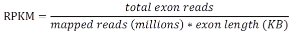

RPKM = reads per kilobase per million mapped reads,

For most statistical differential expression or abundance analysis methods, such as *`edgeR`* or *`DESeq2`*, the raw count values should be used as input. The usage of RPKM values should be restricted to specialty applications required by some users, e.g. manually comparing the expression levels of different genes or features. The following calculates the RPKM values:

```r
rpkmDFeByg <- apply(countDFeByg, 2, function(x) returnRPKM(counts=x, ranges=eByg)) # change to TRUE
write.table(rpkmDFeByg, "results/rpkmDFeByg.xls", col.names=NA, quote=FALSE, sep="\t")
rpkmDFeByg[1:4,1:8]
```

[Back to Table of Contents](http://biocluster.ucr.edu/~rkaundal/workshops/R_mar2016/RNAseq.html)

## 4.7 Sample-wise correlation analysis

### 4.7.1 Clustering of samples using *`RPKM`* expression values

QC check of the sample reproducibility could be done by computing a correlating matrix and plotting it as a tree. The following generates the dendrogram using the RPKM normalized expression values and the Spearman’s correlation coefficient.

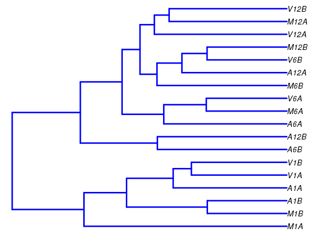

```r
library(ape)
d <- cor(rpkmDFeByg, method="spearman")
hc <- hclust(dist(1-d))
pdf("./results/Sample_tree_rpkm.pdf") # save the tree as PDF file
plot.phylo(as.phylo(hc), type="p", edge.col=4, edge.width=3, show.node.label=TRUE, no.margin=TRUE)
dev.off()
```

**Figure 3:** Correlation dendrogram of samples based on *`RPKM`* values.

### 4.7.2 Clustering of samples with *`rlog`* values

The following computes the sample-wise Spearman correlation coefficients from the *`rlog`* (regularized-logarithm) transformed expression values generated with the *`DESeq2`* package ([Link](http://rpackages.ianhowson.com/bioc/DESeq2/man/rlog.html)). After transformation to a distance matrix, hierarchical clustering is performed with the *`hclust`* function and the result is plotted as a dendrogram ([sample_tree.pdf](http://biocluster.ucr.edu/~rkaundal/workshops/R_mar2016/results/Sample_tree_rlog.pdf)). In combination with Spearman correlation, the results of the two clustering methods are often relatively similar.

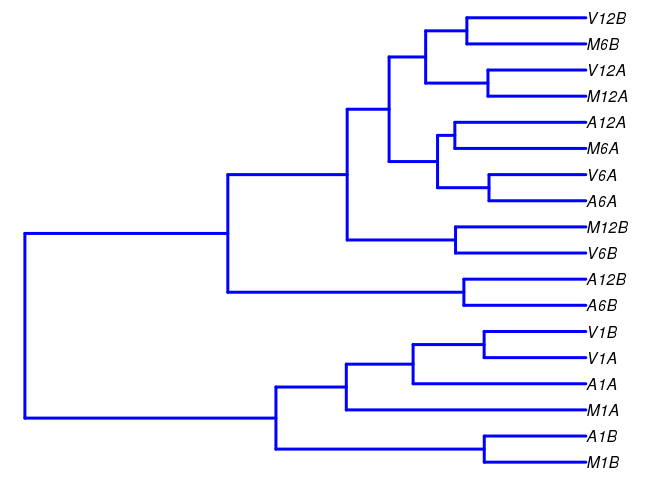

```r
library(DESeq2)
countDF <- as.matrix(read.table("./results/countDFeByg.xls"))
colData <- data.frame(row.names=targetsin(args)$SampleName, condition=targetsin(args)$Factor)
dds <- DESeqDataSetFromMatrix(countData = countDF, colData = colData, design = ~ condition)
d <- cor(assay(rlog(dds)), method="spearman")
hc <- hclust(dist(1-d))
pdf("./results/Sample_tree_rlog.pdf")
plot.phylo(as.phylo(hc), type="p", edge.col=4, edge.width=3, show.node.label=TRUE, no.margin=TRUE)
dev.off()
```

**Figure 4:** Correlation dendrogram of samples based on *`rlog`* values.

[Back to Table of Contents](http://biocluster.ucr.edu/~rkaundal/workshops/R_mar2016/RNAseq.html)

## 4.8 Analysis of differentially expressed genes (DEGs)

### 4.8.1 DEG analysis with *`edgeR`*

The following *`run_edgeR`* function is a convenience wrapper for identifying differentially expressed genes (DEGs) in batch mode with *`edgeR`*’s GLM (Generalized Linear Model) method [Robinson, McCarthy, and Smyth 2010] for any number of pairwise sample comparisons specified under the *`cmp`* argument. Users are strongly encouraged to consult the [*`edgeR`*](http://bioconductor.org/packages/release/bioc/manuals/edgeR/man/edgeR.pdf) vignette for more detailed information on this topic and how to properly run *`edgeR`* on data sets with more complex experimental designs.

```r
countDF <- read.table("./results/countDFeByg.xls") # change to TRUE
cmp <- readComp(args, format="matrix", delim="-")
cmp[[1]]
edgeDF <- run_edgeR(countDF=countDF, targets=targetsin(args), cmp=cmp[[1]], independent=FALSE, mdsplot="")
write.table(edgeDF, "./results/edgeRcomp.xls", quote=FALSE, sep="\t", col.names = NA)
```

**Dispersion** is a measure of the degree of inter-library variation and so estimating the common dispersion gives an idea of overall variability across the genome. Gene-specific dispersion estimation is necessary so that genes that behave consistently across replicates should rank more highly than genes that do not. **Biological CV (BCV)** is the coefficient of variation with which the (unknown) true abundance of the gene varies between replicate RNA samples. The BCV is the square root of the dispersion parameter. In this example, we have a common dispersion estimate of 0.19069, which (take square root) gives an estimate of the coefficient of variation of 0.4367. We interpret this as saying that the true abundance for each gene can vary up or down by 43.67% between replicates. It represents the CV that would remain between biological replicates if sequencing depth could be increased indefinitely.

**Fold change (FC)**: Fold change, generally refers to the ratio of average expression between two groups. When you’re comparing two things: A and B, the fold change is A/B. A and B could be data sets reflecting gene expression measured under different conditions. If *gene1* is 2-fold higher in A, the A/B ratio for *gene1* is 2. If *gene2* is 2-fold higher in B than A, the *gene2* ratio is 0.5. However, edgeR displays the log2 of the ratio.

**logFC**: For a particular gene, a log2 fold change of −1 for condition treated vs untreated means that the treatment induces a change in observed expression level of 2^−1 = 0.5 compared to the untreated condition. Genes up or down by a given amount (i.e. two-fold) have the same distance from equality, but the sign (+/-) changes. Thus *gene1* would have logFC: 1, and *gene2* would have logFC: -1, reflecting 2-fold up or down respectively. In log2 space, the numbers are close enough. For instance: -2 is 4-fold down, -1 is 2-fold down, 0 is equal in A and B (a ratio of 1), 1 is 2-fold up, 2 is 4-fold up, etc. To convert the logFC value from edgeR (which are essentially ratios of the normalized count values per gene) into an up or down ratio, you simply take 2 to the power of the logFC number. For example, for a gene with logFC of 0.5 or -0.5, the ratio is 2^0.5 = 1.4, or 2^-0.5 = 0.7, respectively.

**False Discovery Rate (FDR)**: FDR values are calculated using the method of Benjamini and Hochberg from the distribution of 2-way ANOVA p-values, and fold-change values are calculated on a linear scale using least squares mean.

**Filter and plot DEG results for up and down regulated genes**: Because of the small size of the toy data set used by this vignette, the *FDR* value has been set to a relatively high threshold (here 20%). More commonly used *FDR* cutoffs are 1% or 5%. The definition of ‘*up*’ and ‘*down*’ is given in the corresponding help file. To open it, type *`?filterDEGs`* in the R console.

```r
DEG_list <- filterDEGs(degDF=edgeDF, filter=c(Fold=2, FDR=20))
```

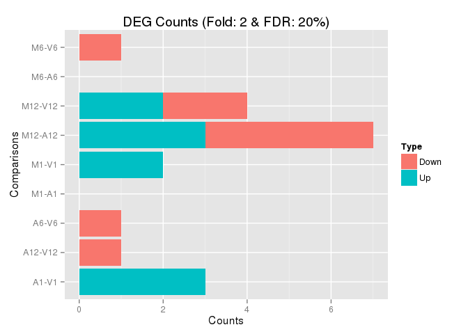

**Figure 5:** Up and down regulated DEGs identified by *`edgeR`*.

```r
names(DEG_list)
```

```
## [1] "UporDown" "Up"       "Down"     "Summary"
```

```r
DEG_list$Summary
```

```
##         Comparisons Counts_Up_or_Down Counts_Up Counts_Down
## M1-A1         M1-A1                 0         0           0
## M1-V1         M1-V1                 2         2           0
## A1-V1         A1-V1                 3         3           0
## M6-A6         M6-A6                 0         0           0
## M6-V6         M6-V6                 1         0           1
## A6-V6         A6-V6                 1         0           1
## M12-A12     M12-A12                 7         3           4
## M12-V12     M12-V12                 4         2           2
## A12-V12     A12-V12                 1         0           1
```

[Back to Table of Contents](http://biocluster.ucr.edu/~rkaundal/workshops/R_mar2016/RNAseq.html)

### 4.8.2 DEG analysis with *`DESeq2`*

The following *`run_DESeq2`* function is a convenience wrapper for identifying DEGs in batch mode with *`DESeq2`* [Love, Huber, and Anders 2014] for any number of pairwise sample comparisons specified under the *`cmp`* argument. Users are strongly encouraged to consult the [*`DESeq2`*](http://www.bioconductor.org/packages/devel/bioc/vignettes/DESeq2/inst/doc/DESeq2.pdf) vignette for more detailed information on this topic and how to properly run *`DESeq2`* on data sets with more complex experimental designs.

```r
countDF <- read.table("./results/countDFeByg.xls")
cmp <- readComp(args, format="matrix", delim="-")
degseqDF <- run_DESeq2(countDF=countDF, targets=targetsin(args), cmp=cmp[[1]], independent=FALSE)
write.table(degseqDF, "./results/DESeq2comp.xls", quote=FALSE, sep="\t", col.names = NA)
```

Filter and plot DEG results for up and down regulated genes

```r
DEG_list2 <- filterDEGs(degDF=degseqDF, filter=c(Fold=2, FDR=20))
```

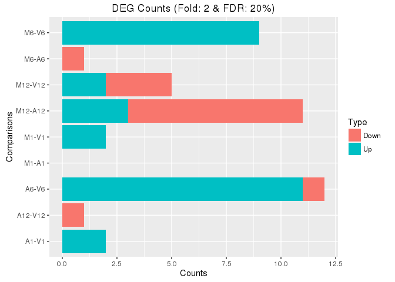

**Figure 6:** Up and down regulated DEGs identified by *`DESeq2`*.

```r
names(DEG_list2)
```

```
## [1] "UporDown" "Up"       "Down"     "Summary"
```

```r
DEG_list2$Summary[1:4,]
```

```
##       Comparisons Counts_Up_or_Down Counts_Up Counts_Down
## M1-A1       M1-A1                 0         0           0
## M1-V1       M1-V1                 2         2           0
## A1-V1       A1-V1                 2         2           0
## M6-A6       M6-A6                 1         0           1
```

[Back to Table of Contents](http://biocluster.ucr.edu/~rkaundal/workshops/R_mar2016/RNAseq.html)

## 4.9 Venn Diagrams

The function *`overLapper`* can compute Venn intersects for large numbers of sample sets (up to 20 or more) and *`vennPlot`* can plot 2-5 way Venn diagrams. A useful feature is the possiblity to combine the counts from several Venn comparisons with the same number of sample sets in a single Venn diagram (here for 4 up and down DEG sets from the *`edgeR`* results).

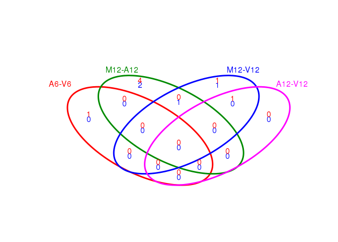

```r
vennsetup <- overLapper(DEG_list$Up[6:9], type="vennsets")
vennsetdown <- overLapper(DEG_list$Down[6:9], type="vennsets")
vennPlot(list(vennsetup, vennsetdown), mymain="", mysub="", colmode=2, ccol=c("blue", "red"))
```

**Figure 7:** Venn Diagram for 4 Up and Down DEG Sets.

[Back to Table of Contents](http://biocluster.ucr.edu/~rkaundal/workshops/R_mar2016/RNAseq.html)

## 4.10 GO term enrichment analysis

### 4.10.1 Obtain gene-to-GO mappings (Part I)

The following shows how to obtain gene-to-GO mappings from *`biomaRt`* (here for *A. thaliana*) and how to organize them for the downstream GO term enrichment analysis. Alternatively, the gene-to-GO mappings can be obtained for many organisms from Bioconductor’s *`*.db`* genome annotation packages or GO annotation files provided by various genome databases. For each annotation this relatively slow preprocessing step needs to be performed only once. Subsequently, the preprocessed data can be loaded with the *`load`* function as shown in the next subsection.

```r
library("biomaRt")
listMarts(host="plants.ensembl.org") # To choose BioMart database
m <- useMart("plants_mart", host="plants.ensembl.org"); listDatasets(m)
m <- useMart("plants_mart", host="plants.ensembl.org", dataset="athaliana_eg_gene")
listAttributes(m) # Choose data types you want to download
go <- getBM(attributes=c("go_accession", "tair_locus", "go_namespace_1003"), mart=m)
go <- go[go[,3]!="",]; go[,3] <- as.character(go[,3])
dir.create("./data/GO")
write.table(go, "data/GO/GOannotationsBiomart_mod.txt", quote=FALSE, row.names=FALSE, col.names=FALSE, sep="\t")
catdb <- makeCATdb(myfile="data/GO/GOannotationsBiomart_mod.txt", lib=NULL, org="", colno=c(1,2,3), idconv=NULL)
save(catdb, file="data/GO/catdb.RData")
```

### 4.10.2 Batch GO term enrichment analysis (Part II)

Apply the enrichment analysis to the DEG sets obtained in the above differential expression analysis. Note, in the following example the *FDR* filter is set here to an unreasonably high value, simply because of the small size of the toy data set used in this vignette. Batch enrichment analysis of many gene sets is performed with the *`GOCluster_Report`* function. When *`method="all"`*, it returns all GO terms passing the p-value cutoff specified under the *`cutoff`* arguments. When *`method="slim"`*, it returns only the GO terms specified under the *`myslimv`* argument. The given example shows how one can obtain such a GO slim vector from BioMart for a specific organism.

```r
load("data/GO/catdb.RData")
DEG_list <- filterDEGs(degDF=edgeDF, filter=c(Fold=2, FDR=50), plot=FALSE)
up_down <- DEG_list$UporDown; names(up_down) <- paste(names(up_down), "_up_down", sep="")
up <- DEG_list$Up; names(up) <- paste(names(up), "_up", sep="")
down <- DEG_list$Down; names(down) <- paste(names(down), "_down", sep="")
DEGlist <- c(up_down, up, down)
DEGlist <- DEGlist[sapply(DEGlist, length) > 0]
BatchResult <- GOCluster_Report(catdb=catdb, setlist=DEGlist, method="all", id_type="gene", CLSZ=2, cutoff=0.9, gocats=c("MF", "BP", "CC"), recordSpecGO=NULL)
write.table(BatchResult, "./results/GO_BatchResult.xls", quote=FALSE, sep="\t", row.names = FALSE)

library("biomaRt"); m <- useMart("plants_mart", host="plants.ensembl.org", dataset="athaliana_eg_gene")
goslimvec <- as.character(getBM(attributes=c("goslim_goa_accession"), mart=m)[,1])
BatchResultslim <- GOCluster_Report(catdb=catdb, setlist=DEGlist, method="slim", id_type="gene", myslimv=goslimvec, CLSZ=10, cutoff=0.01, gocats=c("MF", "BP", "CC"), recordSpecGO=NULL)
write.table(BatchResultslim, "./results/GO_BatchResultslim.xls", quote=FALSE, sep="\t", row.names = FALSE)
```

### 4.10.3 Plot the batch GO term results (Part III)

The *`data.frame`* generated by *`GOCluster_Report`* can be plotted with the *`goBarplot`* function. Because of the variable size of the sample sets, it may not always be desirable to show the results from different DEG sets in the same bar plot. Plotting single sample sets is achieved by subsetting the input data frame as shown in the first line of the following example.

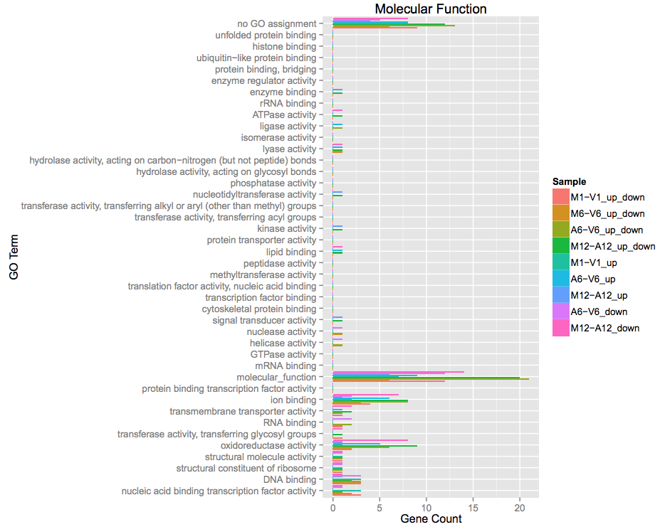

```r
gos <- BatchResultslim[grep("M6-V6_up_down", BatchResultslim$CLID), ]
gos <- BatchResultslim
pdf("./results/GOslimbarplotMF.pdf", height=8, width=10); goBarplot(gos, gocat="MF"); dev.off()
goBarplot(gos, gocat="BP")
goBarplot(gos, gocat="CC")
```

**Figure 8:** GO Slim Barplot for MF Ontology.

[Back to Table of Contents](http://biocluster.ucr.edu/~rkaundal/workshops/R_mar2016/RNAseq.html)

## 4.11 Gene-wise clustering

Note: the following plots the scaled expression values (here RPKMs) in the form of a heatmap.

```r
library(lattice); library(gplots)
```

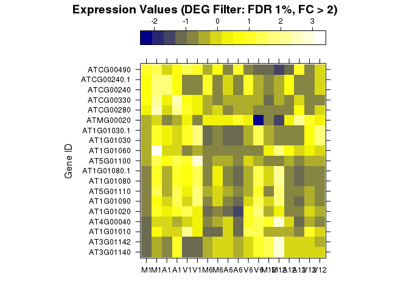

```r
rpkmDFeByg <- read.table("./results/rpkmDFeByg.xls")
y <- rpkmDFeByg[unlist(DEG_list$UporDown),]
colnames(y) <- targetsin(args)$Factor
y <- t(scale(t(as.matrix(y))))
y <- y[order(y[,1]),]
levelplot(t(y), height=0.2, col.regions=colorpanel(40, "darkblue", "yellow", "white"), main="Expression Values (DEG Filter: FDR 1%, FC > 2)", colorkey=list(space="top"), xlab="", ylab="Gene ID")
```

**Figure 9:** Heat map of DEGs based on *`RPKM`* expression values.

[Back to Table of Contents](http://biocluster.ucr.edu/~rkaundal/workshops/R_mar2016/RNAseq.html)

**Alternatively**, one can also perform hierarchical clustering on the *`rlog`* transformed expression matrix subsetted by the DEGs identified in the above differential expression analysis. It uses a Pearson correlation-based distance measure and complete linkage for cluster joining.

```r
library(pheatmap)
geneids <- unique(as.character(unlist(DEG_list[[1]])))
y <- assay(rlog(dds))[geneids, ]
pdf("./results/heatmap_rlog.pdf")
pheatmap(y, scale="row", clustering_distance_rows="correlation", clustering_distance_cols="correlation")
dev.off()
```

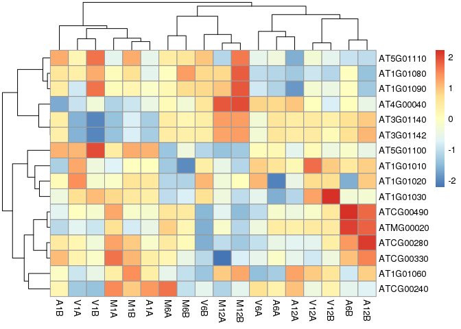

```r
pheatmap(y, scale="row", clustering_distance_rows="correlation", clustering_distance_cols="correlation")
```

**Figure 10:** Heat map of DEGs based on *`rlog`* transformed expression values.